# LCA Meausrement Invariance

Lab Created By Karen Nylund-Gibson & Dina Arch, Example from Nylund-Gibson et al. (2022)

2024-11-18

# LCA Measurement Invariance

Example is related (but not exactly the same) to *The Utility of Latent Class Analysis to Understand Heterogeneity in Youth Coping Strategies: A Methodological Introduction* (Nylund-Gibson et al., 2022) published in Behavior Disorders. See here: https://doi.org/10.1177/01987429211067214

Load packages

```r
library(tidyverse)
library(haven)
library(glue)
library(MplusAutomation)
library(rhdf5)
library(here)
library(janitor)
library(gt)
library(semPlot)
library(reshape2)
library(cowplot)
library(filesstrings)
library(hrbrthemes)
library(poLCA)
library(haven)
library(psych)
```

Read in data

(Note: `bd` stands for Behavior Disorders)

```r
bd <-read_csv(here("data","bd.csv"))


describe(bd)
```

```
##             vars   n     mean       sd  median  trimmed     mad   min     max
## id             1 589 29617.46 40724.97 26930.0 27666.76 5796.97 22000 1010101
## FEMALE         2 580     0.54     0.50     1.0     0.55    0.00     0       1
## studyethraw    3 445     3.78     1.67     3.0     3.58    1.48     1       8
## ETHN_CMP       4 589     3.36     1.04     3.0     3.36    1.48     1       5
## do1            5 446     0.49     0.50     0.0     0.49    0.00     0       1
## do2            6 446     0.09     0.28     0.0     0.00    0.00     0       1
## do3            7 444     0.52     0.50     1.0     0.52    0.00     0       1
## do4            8 443     0.42     0.49     0.0     0.40    0.00     0       1
## do5            9 445     0.51     0.50     1.0     0.52    0.00     0       1
## do6           10 444     0.23     0.42     0.0     0.16    0.00     0       1
## do7           11 445     0.41     0.49     0.0     0.38    0.00     0       1
## psolv1        12 444     0.41     0.49     0.0     0.39    0.00     0       1
## psolv2        13 443     0.53     0.50     1.0     0.53    0.00     0       1
## psolv3        14 444     0.42     0.49     0.0     0.40    0.00     0       1
## psolv4        15 444     0.43     0.50     0.0     0.41    0.00     0       1
## psolv5        16 444     0.30     0.46     0.0     0.25    0.00     0       1
## psolv6        17 443     0.59     0.49     1.0     0.61    0.00     0       1
## psolv7        18 442     0.55     0.50     1.0     0.56    0.00     0       1
## psolv8        19 442     0.50     0.50     0.0     0.50    0.00     0       1
## SOC_STRS      20 442     0.71     0.45     1.0     0.77    0.00     0       1
## BOTHR_U       21 429     2.37     1.20     2.0     2.26    1.48     1       5
## negmood1      22 447     1.79     0.70     1.6     1.71    0.89     1       4
## posmood1      23 447     3.00     0.64     3.0     3.04    0.59     1       4
##              range  skew kurtosis      se
## id          988101 23.69   567.43 1678.04
## FEMALE           1 -0.16    -1.98    0.02
## studyethraw      7  1.08     0.59    0.08
## ETHN_CMP         4 -0.02    -0.76    0.04
## do1              1  0.03    -2.00    0.02
## do2              1  2.91     6.49    0.01
## do3              1 -0.06    -2.00    0.02
## do4              1  0.33    -1.89    0.02
## do5              1 -0.06    -2.00    0.02
## do6              1  1.31    -0.28    0.02
## do7              1  0.38    -1.86    0.02
## psolv1           1  0.36    -1.88    0.02
## psolv2           1 -0.10    -1.99    0.02
## psolv3           1  0.32    -1.90    0.02
## psolv4           1  0.28    -1.93    0.02
## psolv5           1  0.88    -1.22    0.02
## psolv6           1 -0.37    -1.87    0.02
## psolv7           1 -0.21    -1.96    0.02
## psolv8           1  0.01    -2.00    0.02
## SOC_STRS         1 -0.95    -1.10    0.02
## BOTHR_U          4  0.60    -0.62    0.06
## negmood1         3  0.79    -0.06    0.03
## posmood1         3 -0.57    -0.08    0.03
```

## Descriptive Statistics

Looking at the observed proportions for funsies.

```r
bd %>%
  pivot_longer(do1:do7, names_to = "variable") %>%
  drop_na() %>%
  group_by(variable) %>%
  summarise(prop = sum(value)/n(),
            n = n())
```

```
## # A tibble: 7 × 3
##   variable   prop     n
##   <chr>     <dbl> <int>
## 1 do1      0.501    405
## 2 do2      0.0864   405
## 3 do3      0.517    404
## 4 do4      0.412    403
## 5 do5      0.522    404
## 6 do6      0.230    404
## 7 do7      0.401    404
```

```r
ds <- bd %>%
  pivot_longer(do1:do7, names_to = "variable") %>%
  drop_na() %>%
  group_by(variable) %>%
  summarise(prop = sum(value)/n(),
            n = n())

prop_table <- ds %>%
  gt () %>%
  tab_header(title = md("**Descriptive Summary**")) %>%
  cols_label(
    variable = "Variable",
    n = md("*N*"),
    prop = md("Proportion Endorsed")
  ) %>%
  fmt_number(c(2),
             decimals = 2) %>%
  cols_align(
    align = "center",
    columns = prop
  )

prop_table
```

**Descriptive Summary**

| Variable | Proportion Endorsed | *N* |
| --- | --- | --- |
| do1 | 0.50 | 405 |
| do2 | 0.09 | 405 |
| do3 | 0.52 | 404 |
| do4 | 0.41 | 403 |
| do5 | 0.52 | 404 |
| do6 | 0.23 | 404 |
| do7 | 0.40 | 404 |

```r
# Save as a Word doc
#gtsave(prop_table, here("figures", "prop_table.docx"))
```

## LCA Enumeration (Entire Sample)

```r
lca_bd  <- lapply(1:6, function(k) {
  lca_enum  <- mplusObject(

    TITLE = glue("LCA {k}-Class (Entire Sample)"),

    VARIABLE = glue(
    "categorical = do1-do7;
     usevar = do1-do7;
     classes = c({k}); "),

  ANALYSIS =
   "estimator = mlr;
    type = mixture;
    starts = 500 100;
    processors = 10;",

  OUTPUT = "sampstat residual tech11 tech14 svalues;",

  PLOT =
    "type = plot3;
    series = do1-do7(*);",

  usevariables = colnames(bd),
  rdata = bd)

lca_enum_fit <- mplusModeler(lca_enum,
                            dataout=glue(here("enum_total", "db.dat")),
                            modelout=glue(here("enum_total", "c{k}_bd.inp")) ,
                            check=TRUE, run = TRUE, hashfilename = FALSE)
})
```

### Table of Fit

```r
source("enum_table.txt")

output_total <- readModels(here("enum_total"), quiet = TRUE)

enum_table(output_total, 1:6)
```

**Model Fit Summary Table**<sup>1</sup>

| Classes | Par | Min. Class Size | *LL* | BIC | aBIC | CAIC | AWE | BLRT | VLMR | BF | *cmPk* |
| --- | --- | --- | --- | --- | --- | --- | --- | --- | --- | --- | --- |
| LCA 1-Class (Entire Sample) | 7 | 100.00 | −1,895.71 | 3,834.13 | 3,811.91 | 3,841.13 | 3,897.83 | – | – | 0.00 | <.001 |
| LCA 2-Class (Entire Sample) | 15 | 37.23 | −1,834.42 | 3,760.35 | 3,712.75 | 3,775.35 | 3,896.86 | <.001 | <.001 | >100 | 1.00 |
| LCA 3-Class (Entire Sample) | 23 | 25.18 | −1,817.52 | 3,775.35 | 3,702.36 | 3,798.35 | 3,984.66 | <.001 | 0.37 | >100 | <.001 |
| LCA 4-Class (Entire Sample) | 31 | 4.15 | −1,805.83 | 3,800.77 | 3,702.39 | 3,831.77 | 4,082.88 | 0.04 | 0.35 | >100 | <.001 |
| LCA 5-Class (Entire Sample) | 39 | 4.24 | −1,800.81 | 3,839.54 | 3,715.77 | 3,878.54 | 4,194.45 | 1.00 | 0.26 | >100 | <.001 |
| LCA 6-Class (Entire Sample) | 47 | 3.43 | −1,796.29 | 3,879.29 | 3,730.13 | 3,926.29 | 4,307.00 | 1.00 | 0.57 | – | <.001 |

<sup>1</sup> *Note.* Par = Parameters; *LL* = model log likelihood; BIC = Bayesian information criterion; aBIC = sample size adjusted BIC; CAIC = consistent Akaike information criterion; AWE = approximate weight of evidence criterion; BLRT = bootstrapped likelihood ratio test p-value; cmPk = approximate correct model probability.

### 2-Class Probability Plot (Entire Sample)

Boys and girls together

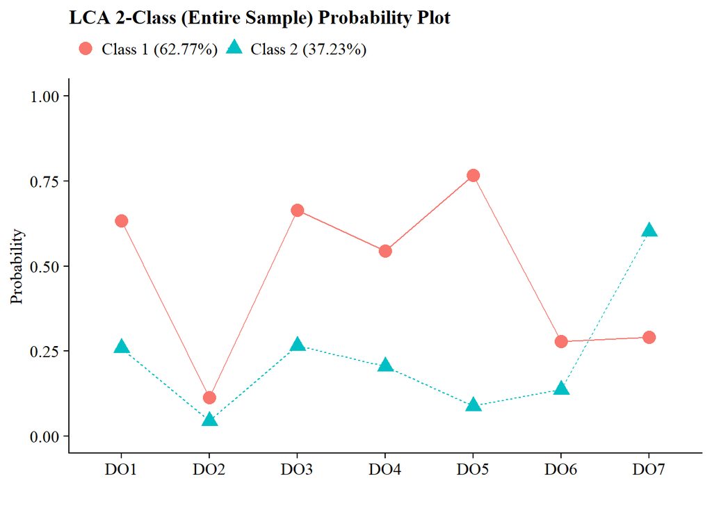

```r
source("plot_lca.txt")

plot_lca(model_name = output_total$c2_bd.out)
```

## LCA Enumeration (Males Only)

```r
lca_bd  <- lapply(1:6, function(k) {
  lca_enum  <- mplusObject(

    TITLE = glue("{k}-Class (Males Only)"),

    VARIABLE = glue(
    "categorical = do1-do7;
     usevar = do1-do7;
     useobs = female == 0;
     classes = c({k});"),

  ANALYSIS =
   "estimator = mlr;
    type = mixture;
    starts = 500 100;
    processors = 10;",

  OUTPUT = "sampstat residual tech11 tech14 svalues;",

  PLOT =
    "type = plot3;
    series = do1-do7(*);",

  usevariables = colnames(bd),
  rdata = bd)

lca_enum_fit <- mplusModeler(lca_enum,
                            dataout=glue(here("enum_males", "db.dat")),
                            modelout=glue(here("enum_males", "c{k}_bd_males.inp")) ,
                            check=TRUE, run = TRUE, hashfilename = FALSE)
})
```

### Table of Fit

```r
source("enum_table.txt")

output_males <- readModels(here("enum_males"), quiet = TRUE)

enum_table(output_males, 1:6)
```

**Model Fit Summary Table**<sup>1</sup>

| Classes | Par | Min. Class Size | *LL* | BIC | aBIC | CAIC | AWE | BLRT | VLMR | BF | *cmPk* |
| --- | --- | --- | --- | --- | --- | --- | --- | --- | --- | --- | --- |
| 1-Class (Males Only) | 7 | 100.00 | −813.75 | 1,664.59 | 1,642.41 | 1,671.59 | 1,722.68 | – | – | 0.00 | <.001 |
| 2-Class (Males Only) | 15 | 30.11 | −779.58 | 1,638.62 | 1,591.10 | 1,653.62 | 1,763.10 | <.001 | 0.00 | >100 | 1.00 |
| 3-Class (Males Only) | 23 | 26.96 | −764.31 | 1,650.47 | 1,577.61 | 1,673.48 | 1,841.34 | <.001 | 0.74 | >100 | 0.00 |
| 4-Class (Males Only) | 31 | 5.42 | −755.15 | 1,674.55 | 1,576.34 | 1,705.55 | 1,931.80 | <.001 | 0.01 | >100 | <.001 |
| 5-Class (Males Only) | 39 | 3.82 | −748.61 | 1,703.85 | 1,580.29 | 1,742.85 | 2,027.48 | 0.38 | 0.02 | >100 | <.001 |
| 6-Class (Males Only) | 47 | 2.64 | −742.53 | 1,734.07 | 1,585.17 | 1,781.07 | 2,124.09 | 0.43 | 0.06 | – | <.001 |

<sup>1</sup> *Note.* Par = Parameters; *LL* = model log likelihood; BIC = Bayesian information criterion; aBIC = sample size adjusted BIC; CAIC = consistent Akaike information criterion; AWE = approximate weight of evidence criterion; BLRT = bootstrapped likelihood ratio test p-value; cmPk = approximate correct model probability.

### Males: Probability Plot

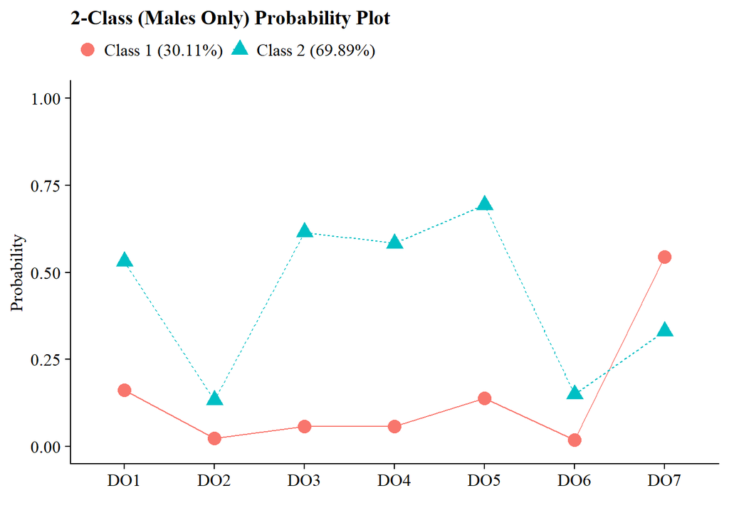

```r
source("plot_lca.txt")

male_plot <- plot_lca(model_name = output_males$c2_bd_males.out)
male_plot
```

## LCA Enumeration (Females Only)

```r
lca_bd  <- lapply(1:6, function(k) {
  lca_enum  <- mplusObject(

    TITLE = glue("{k}-Class (Females Only)"),

    VARIABLE = glue(
    "categorical = do1-do7;
     usevar = do1-do7;
     useobs = female == 1;
     classes = c({k});"),

  ANALYSIS =
   "estimator = mlr;
    type = mixture;
    starts = 500 100;
    processors = 10;",

  OUTPUT = "sampstat residual tech11 tech14 svalues;",

  PLOT =
    "type = plot3;
    series = do1-do7(*);",

  usevariables = colnames(bd),
  rdata = bd)

lca_enum_fit <- mplusModeler(lca_enum,
                            dataout=glue(here("enum_females", "db.dat")),
                            modelout=glue(here("enum_females", "c{k}_bd_females.inp")) ,
                            check=TRUE, run = TRUE, hashfilename = FALSE)
})
```

### Table of Fit

Enumeration Table Shortcut

```r
source("enum_table.txt")

output_females <- readModels(here("enum_females"), quiet = TRUE)

enum_table(output_females, 1:6)
```

**Model Fit Summary Table**<sup>1</sup>

| Classes | Par | Min. Class Size | *LL* | BIC | aBIC | CAIC | AWE | BLRT | VLMR | BF | *cmPk* |
| --- | --- | --- | --- | --- | --- | --- | --- | --- | --- | --- | --- |
| 1-Class (Females Only) | 7 | 100.00 | −1,025.03 | 2,088.37 | 2,066.18 | 2,095.37 | 2,147.67 | – | – | 0.00 | <.001 |
| 2-Class (Females Only) | 15 | 41.13 | −992.58 | 2,067.25 | 2,019.71 | 2,082.25 | 2,194.34 | <.001 | <.001 | >100 | 1.00 |
| 3-Class (Females Only) | 23 | 10.86 | −985.87 | 2,097.61 | 2,024.71 | 2,120.61 | 2,292.47 | 0.67 | 0.43 | >100 | <.001 |
| 4-Class (Females Only) | 31 | 3.95 | −979.91 | 2,129.45 | 2,031.19 | 2,160.45 | 2,392.09 | 0.67 | 0.36 | >100 | <.001 |
| 5-Class (Females Only) | 39 | 2.83 | −974.62 | 2,162.66 | 2,039.04 | 2,201.65 | 2,493.07 | 1.00 | 0.39 | >100 | <.001 |
| 6-Class (Females Only) | 47 | 3.01 | −970.19 | 2,197.57 | 2,048.60 | 2,244.57 | 2,595.77 | 1.00 | 0.18 | – | <.001 |

<sup>1</sup> *Note.* Par = Parameters; *LL* = model log likelihood; BIC = Bayesian information criterion; aBIC = sample size adjusted BIC; CAIC = consistent Akaike information criterion; AWE = approximate weight of evidence criterion; BLRT = bootstrapped likelihood ratio test p-value; cmPk = approximate correct model probability.

### Females: Probability Plot

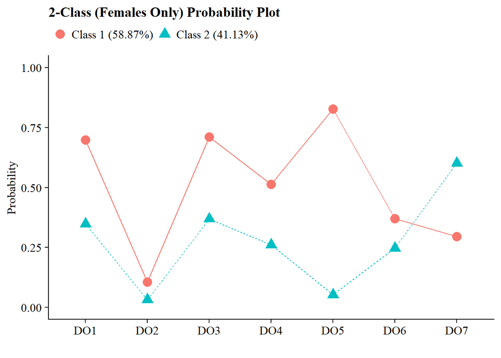

```r
source("plot_lca.txt")

female_plot <- plot_lca(model_name = output_females$c2_bd_females.out)
female_plot
```

## Compare Plots

This allows us to have a visual understanding of the latent classes for males and females. When we test measurement invarinace, we would estimate one set of classes for both genders. So having the group specific solution being simliar (e.g., nubmber of classes is the same and the profiles look similiar, you’d name them the same across groups)

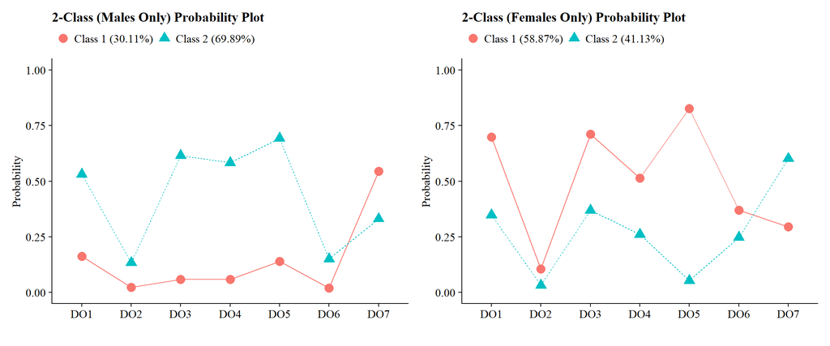

```r
library(patchwork)

male_plot + female_plot
```

### Measurement Invariance

```r
invar  <- mplusObject(

 TITLE = "LCA - Measurement Invariance",

  VARIABLE =
  "categorical = do1-do7;
   usevar =  do1-do7;
   knownclass = g (female);
   missing are all (999);
   classes = g(2) c(2);",

  ANALYSIS =
   "estimator = mlr;
    type = mixture;
    starts = 500 100;",

  MODEL=
   "
%overall%

 c on g;

 %g#1.c#1%
 [do1$1 - do7$1] (1-7);

 %g#1.c#2%
 [do1$1 - do7$1] (8-14);

 %g#2.c#1%
 [do1$1 - do7$1](1-7);

 %g#2.c#2%
 [do1$1 - do7$1](8-14);",

  OUTPUT = "patterns tech10 tech11 tech14",

  usevariables = colnames(bd),
  rdata = bd)

invar_fit <- mplusModeler(invar,
                dataout=here("mplus", "invar.dat"),
                modelout=here("mplus", "invar.inp") ,
                check=TRUE, run = TRUE, hashfilename = FALSE)
```

### Measurement Non-Invariance

This is the knownclass model that allows the esitmates to be freely esitmated.

```r
noninvar  <- mplusObject(

 TITLE = "LCA - Measurement Non-Invariance",

  VARIABLE =
  "categorical = do1-do7;
   usevar =  do1-do7;
   knownclass = g (female);
   missing are all (999);
   classes = g(2) c(2);",

  ANALYSIS =
   "estimator = mlr;
    type = mixture;
    starts = 500 100;",

  MODEL=
   "
%overall%

 c on g;

 %g#1.c#1%
 [do1$1 - do7$1];

 %g#1.c#2%
 [do1$1 - do7$1];

 %g#2.c#1%
 [do1$1 - do7$1];

 %g#2.c#2%
 [do1$1 - do7$1];",

  OUTPUT = "patterns tech10 tech11 tech14",

  usevariables = colnames(bd),
  rdata = bd)

noninvar_fit <- mplusModeler(noninvar,
                dataout=here("mplus", "noninvar.dat"),
                modelout=here("mplus", "noninvar.inp") ,
                check=TRUE, run = TRUE, hashfilename = FALSE)
```

## Nested Model Testing

Read in both invariant and non-invariant models:

```r
output_invar<- readModels(here("mplus", "invar.out"))
output_noninvar<- readModels(here("mplus", "noninvar.out"))
```

Then use the `compareModels` function from MplusAutomation:

- non-invariant (comparison): This model has **more** parameters.
- invariant (nested): This model has **less** parameters.

```r
# MplusAutomation Method using `compareModels`

compareModels(output_invar,output_noninvar, diffTest = TRUE, show = "summaries")
```

```
##
## ==============
##
## Mplus model comparison
## ----------------------
##
## ------
## Model 1:  C:/Users/dnajiarch/Box/TA - ED 201/Labs/ucsb-mixture-lab8/mplus/invar.out
## Model 2:  C:/Users/dnajiarch/Box/TA - ED 201/Labs/ucsb-mixture-lab8/mplus/noninvar.out
## ------
##
## Model Summary Comparison
## ------------------------
##
##              m1                           m2
## Title        LCA - Measurement Invariance LCA - Measurement Non-Invariance
## Observations 438                          438
## Estimator    MLR                          MLR
## Parameters   17                           31
## LL           -2100.432                    -2074.106
## AIC          4234.864                     4210.212
## BIC          4304.261                     4336.761
##
##   MLR Chi-Square Difference Test for Nested Models Based on Loglikelihood
##   -----------------------------------------------------------------------
##
##   Difference Test Scaling Correction:  1.002436
##   Chi-square difference:  52.5241
##   Diff degrees of freedom:  14
##   P-value:  0
##
##   Note: The chi-square difference test assumes that these models are nested.
##   It is up to you to verify this assumption.
##
##   MLR Chi-Square Difference test for nested models
##   --------------------------------------------
##
##   Difference Test Scaling Correction:
##   Chi-square difference:
##   Diff degrees of freedom:
##   P-value:
##
## Note: The chi-square difference test assumes that these models are nested.
##   It is up to you to verify this assumption.
##
## ==============
```

The chi-square difference test for nested models based on loglikelihood evaluates whether `m2` or the non-invariant model significantly improves in model fit compared to `m1` or the invariant model (assuming that the models are nested). Based on this *p*-value (< 0.001), we would conclude that the non-invariant model fits the data significantly better than the invariant model, or that there is not invariance in the measurement model across gender. For more information on this chi-square test, see [here](https://stats.oarc.ucla.edu/mplus/faq/how-can-i-compute-a-chi-square-test-for-nested-models-with-the-mlr-or-mlm-estimators/), it is under *A test using the log-likelihood*.

**RESULT**: The MLR scaled $\chi^2$ difference test for models based on logliklihood, comparing the nested invariant model and the non-invariant model, is $\chi^2 (14) = 52.524, p < .001$.

Or, you can manually calculate this *p*-value by extracting the values from the output files:

```r
# *0 = null or nested model & *1 = comparison or parent model

# Log Likelihood Values
L0 <- output_invar$summaries$LL
L1 <- output_noninvar$summaries$LL

# LRT equation
lr <- -2*(L0-L1)

# Parameters
p0 <- output_invar[["summaries"]][["Parameters"]]
p1 <- output_noninvar[["summaries"]][["Parameters"]]

# Scaling Correction Factors
c0 <- output_invar[["summaries"]][["LLCorrectionFactor"]]
c1 <- output_noninvar[["summaries"]][["LLCorrectionFactor"]]

# Difference Test Scaling correction
cd <- ((p0*c0)-(p1*c1))/(p0-p1)

# Chi-square difference test(TRd)
TRd <- (lr)/(cd)

# Degrees of freedom
df <- abs(p0 - p1)


# Significance test
(p_diff <- pchisq(TRd, df, lower.tail=FALSE))
```

```
## [1] 2.291869e-06
```

And use a function that creates the sentence for you ;)

```r
# First, I created a function to determine how to handle p-values (don't touch this function)

p_value <- function(x) {
  if (x >= 0.001) {
    return(glue('= ', sprintf('%.3f',x)))
  }
  else {
    return('< .001')
  }
}

# Then, I re-created the sentence using the values we created in the code chunk above:

glue('

     The MLR scaled Chi-square difference test for models based on logliklihood, comparing the nested invariant model and the non-invariant model, is, Chi-square ({df}) = {sprintf("%.3f",TRd)}, p {p_value(p_diff)}.

     ')
```

```
##
## The MLR scaled Chi-square difference test for models based on logliklihood, comparing the nested invariant model and the non-invariant model, is, Chi-square (14) = 52.524, p < .001.
```

Compare fit indices

```r
# Extract model fit data
invar_noninvar <- readModels(here("Mplus"))

enum_extract <- LatexSummaryTable(invar_noninvar,
                keepCols=c("Title", "Parameters", "LL", "BIC", "aBIC",
                           "BLRT_PValue", "T11_VLMR_PValue","Observations"))


fit_table <- enum_extract %>%
  gt() %>%
  tab_header(title = md("**Model Fit Summary Table**")) %>%
  cols_label(
    Title = "Classes",
    Parameters = md("Par"),
    LL = md("*LL*")) %>%
  tab_footnote(
    footnote = md(
    "*Note.* Par = Parameters; *LL* = model log likelihood;
      BIC = Bayesian information criterion;
      aBIC = sample size adjusted BIC;"),
    locations = cells_title()) %>%
  tab_options(column_labels.font.weight = "bold") %>%
  fmt_number(c(3:6),
             decimals = 2) %>%
  tab_style(
    style = list(
      cell_text(weight = "bold")

            ),
    locations = list(cells_body(
     columns = BIC,
     row = BIC == min(BIC[1:2]) # Change this to the number of classes you estimated
    ),
    cells_body(
     columns = aBIC,
     row = aBIC == min(aBIC[1:2])
    )
  )
)

fit_table
```

**Model Fit Summary Table**<sup>1</sup>

| Classes | Par | *LL* | BIC | aBIC | Observations |
| --- | --- | --- | --- | --- | --- |
| LCA - Measurement Invariance | 17 | −2,100.43 | 4,304.26 | 4,250.31 | 438.00 |
| LCA - Measurement Non-Invariance | 31 | −2,074.11 | 4,336.76 | 4,238.38 | 438.00 |

<sup>1</sup> *Note.* Par = Parameters; *LL* = model log likelihood; BIC = Bayesian information criterion; aBIC = sample size adjusted BIC;

# Final Thoughts

Nested model testing indicates that these two 2-class solutions are *not* the same across gender, which may have speculated given the plots. However, the BIC is smaller for the invariant model, compared to the non-invariant model. Would you lable these classes difference across groups? If you would, then perhaps the minor measurement differences across sex do not matter as much and invariance could be reasonable.